# Logistic Regression in R

Zifeng Zhao

week 04 session 01

In this lab, we will practice implementing Logistic regression and its backward selection in `R`.

## 1. Data exploration and visualization

Let’s read in the data stored in `PersonalLoan.csv` and further conduct some data visualization.

```r
rm(list=ls())
total_data <- read.csv("./PersonalLoan.csv", header=T, stringsAsFactors=T)
str(total_data)
```

```
## 'data.frame':    5000 obs. of  12 variables:
##  $ Customer_ID: int  1 2 3 4 5 6 7 8 9 10 ...
##  $ Age        : int  25 45 39 35 35 37 53 50 35 34 ...
##  $ Experience : int  1 19 15 9 8 13 27 24 10 9 ...
##  $ Income     : int  49 34 11 100 45 29 72 22 81 180 ...
##  $ Family     : int  4 3 1 1 4 4 2 1 3 1 ...
##  $ CCAvg      : num  1.6 1.5 1 2.7 1 0.4 1.5 0.3 0.6 8.9 ...
##  $ Education  : Factor w/ 3 levels "AP","G","UG": 3 3 3 2 2 2 2 1 2 1 ...
##  $ Mortgage   : int  0 0 0 0 0 155 0 0 104 0 ...
##  $ CD_Account : Factor w/ 2 levels "No","Yes": 1 1 1 1 1 1 1 1 1 1 ...
##  $ Online     : Factor w/ 2 levels "No","Yes": 1 1 1 1 1 2 2 1 2 1 ...
##  $ CreditCard : Factor w/ 2 levels "No","Yes": 1 1 1 1 2 1 1 2 1 1 ...
##  $ Outcome    : Factor w/ 2 levels "No","Yes": 1 1 1 1 1 1 1 1 1 2 ...
```

Let’s reproduce the side-by-side boxplot and stacked bar chart in the lecture slides.

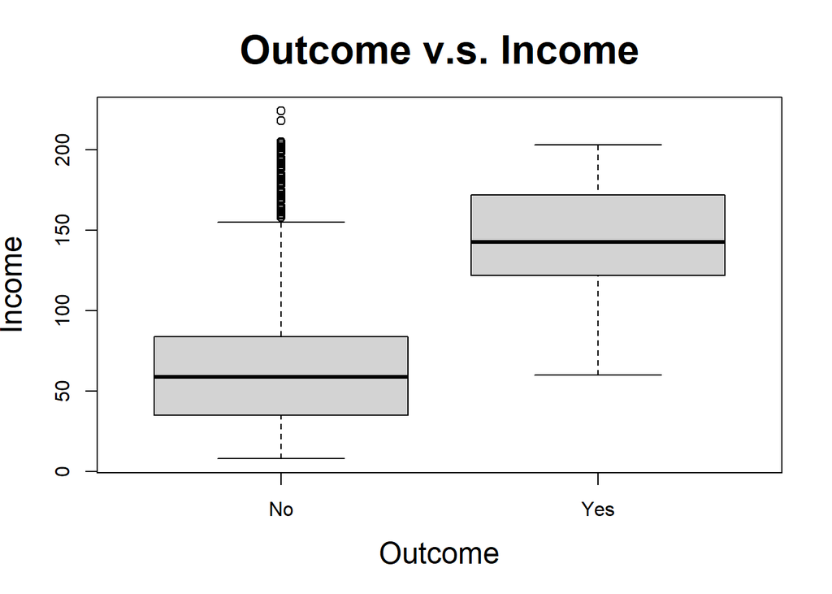

```r
# Boxplot (for numerical X)
plot(total_data$Outcome, total_data$Income, main="Outcome v.s. Income",
  xlab="Outcome", ylab='Income', cex.main=2, cex.lab=1.5)
```

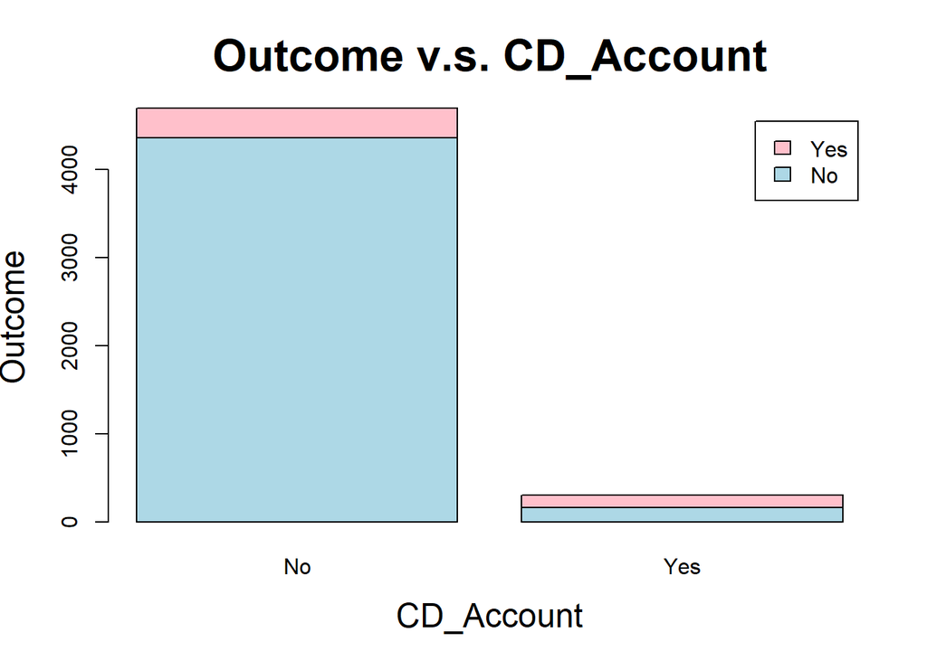

```r
# Stacked bar chart (for categorical X)
counts <- table(total_data$Outcome, total_data$CD_Account)
barplot(counts, col=c("lightblue", "pink"), main="Outcome v.s. CD_Account",
  xlab="CD_Account", ylab='Outcome', legend=rownames(counts), cex.main=2, cex.lab=1.5)
```

## 2. Logistic Regression

### 2.1 Data Partition

Let’s partition the total observed data into a training data (80%) and a test data (20%). To ensure reproducibility, we use the `set.seed()` function in `R` to control the randomness of the training-test split.

```r
set.seed(7)
total_obs <- dim(total_data)[1]
## Data Partition: Training v.s. Test split
train_data_indices <- sample(1:total_obs, 0.8*total_obs)
train_data <- total_data[train_data_indices,]
test_data <- total_data[-train_data_indices,]
# Record the size of training data and test data
train_obs <- dim(train_data)[1]
```

### 2.2 Model Estimation

We first build a logistic regression model for the dependent variable `Outcome` with all predictors `Age+Experience+Income+Family+CCAvg+Education+Mortgage+CD_Account+Online+CreditCard` based on the **training** data using the function `glm()` and name it `lm_full`.

```r
## lm_full will regress on the non-reference level outcome!
lm_full <- glm(Outcome~Age+Experience+Income+Family+CCAvg+Education+Mortgage+CD_Account+Online+CreditCard,
               family='binomial', data=train_data)
summary(lm_full)
```

```
##
## Call:
## glm(formula = Outcome ~ Age + Experience + Income + Family +
##     CCAvg + Education + Mortgage + CD_Account + Online + CreditCard,
##     family = "binomial", data = train_data)
##
## Deviance Residuals:
##     Min       1Q   Median       3Q      Max
## -3.0387  -0.1837  -0.0674  -0.0205   4.2475
##
## Coefficients:
##                 Estimate Std. Error z value Pr(>|z|)
## (Intercept)   -9.4004543  1.9637502  -4.787 1.69e-06 ***
## Age           -0.0061802  0.0725615  -0.085 0.932125
## Experience     0.0179093  0.0723028   0.248 0.804367
## Income         0.0610442  0.0033541  18.200  < 2e-16 ***
## Family         0.6669802  0.0884498   7.541 4.67e-14 ***
## CCAvg          0.1816886  0.0492742   3.687 0.000227 ***
## EducationG     0.0487427  0.2119893   0.230 0.818146
## EducationUG   -4.0345114  0.3028191 -13.323  < 2e-16 ***
## Mortgage       0.0007726  0.0006758   1.143 0.252979
## CD_AccountYes  3.5316254  0.3453944  10.225  < 2e-16 ***
## OnlineYes     -0.8740907  0.1871888  -4.670 3.02e-06 ***
## CreditCardYes -0.9684239  0.2321139  -4.172 3.02e-05 ***
## ---
## Signif. codes:  0 '***' 0.001 '**' 0.01 '*' 0.05 '.' 0.1 ' ' 1
##
## (Dispersion parameter for binomial family taken to be 1)
##
##     Null deviance: 2538.59  on 3999  degrees of freedom
## Residual deviance:  929.78  on 3988  degrees of freedom
## AIC: 953.78
##
## Number of Fisher Scoring iterations: 8
```

### 2.3 Backward Selection via BIC

For backward selection for logistic regression, we again use the function `step()` in `R`. Note that for `step()`, we need to configure the `direction` argument to `backward` and more importantly, we need to configure the `k` argument to `log(train_obs)`, which corresponds to BIC. The default `k` is 2, which corresponds to AIC. Note that in the `step()` function, we need to specify the largest logistic regression model we would like to consider, which is `lm_full` we fitted above. By default, `step()` will print out each step of the backward selection.

```r
lm_bwd <- step(lm_full, direction='backward', k=log(nrow(train_data)))
```

```
## Start:  AIC=1029.31
## Outcome ~ Age + Experience + Income + Family + CCAvg + Education +
##     Mortgage + CD_Account + Online + CreditCard
##
##              Df Deviance    AIC
## - Age         1   929.79 1021.0
## - Experience  1   929.84 1021.1
## - Mortgage    1   931.08 1022.3
## <none>            929.78 1029.3
## - CCAvg       1   943.64 1034.9
## - CreditCard  1   949.07 1040.3
## - Online      1   952.25 1043.5
## - Family      1   993.12 1084.4
## - CD_Account  1  1049.73 1141.0
## - Education   2  1262.22 1345.2
## - Income      1  1561.97 1653.2
##
## Step:  AIC=1021.02
## Outcome ~ Experience + Income + Family + CCAvg + Education +
##     Mortgage + CD_Account + Online + CreditCard
##
##              Df Deviance    AIC
## - Mortgage    1   931.09 1014.0
## - Experience  1   932.22 1015.2
## <none>            929.79 1021.0
## - CCAvg       1   943.65 1026.6
## - CreditCard  1   949.08 1032.0
## - Online      1   952.25 1035.2
## - Family      1   993.12 1076.1
## - CD_Account  1  1049.87 1132.8
## - Education   2  1274.00 1348.6
## - Income      1  1568.08 1651.0
##
## Step:  AIC=1014.03
## Outcome ~ Experience + Income + Family + CCAvg + Education +
##     CD_Account + Online + CreditCard
##
##              Df Deviance    AIC
## - Experience  1   933.41 1008.1
## <none>            931.09 1014.0
## - CCAvg       1   944.24 1018.9
## - CreditCard  1   950.84 1025.5
## - Online      1   953.62 1028.3
## - Family      1   995.29 1069.9
## - CD_Account  1  1052.01 1126.7
## - Education   2  1274.20 1340.5
## - Income      1  1594.29 1668.9
##
## Step:  AIC=1008.06
## Outcome ~ Income + Family + CCAvg + Education + CD_Account +
##     Online + CreditCard
##
##              Df Deviance    AIC
## <none>            933.41 1008.1
## - CCAvg       1   945.71 1012.1
## - CreditCard  1   953.30 1019.6
## - Online      1   955.64 1022.0
## - Family      1   996.32 1062.7
## - CD_Account  1  1055.88 1122.2
## - Education   2  1277.57 1335.6
## - Income      1  1594.63 1661.0
```

Let’s study the output of the backward selection, which predictors are removed during the process?

```r
summary(lm_bwd)
```

```
##
## Call:
## glm(formula = Outcome ~ Income + Family + CCAvg + Education +
##     CD_Account + Online + CreditCard, family = "binomial", data = train_data)
##
## Deviance Residuals:
##     Min       1Q   Median       3Q      Max
## -3.0468  -0.1849  -0.0676  -0.0208   4.2371
##
## Coefficients:
##               Estimate Std. Error z value Pr(>|z|)
## (Intercept)   -9.26593    0.49304 -18.793  < 2e-16 ***
## Income         0.06122    0.00333  18.384  < 2e-16 ***
## Family         0.66271    0.08817   7.516 5.63e-14 ***
## CCAvg          0.17010    0.04895   3.475 0.000512 ***
## EducationG     0.06231    0.20927   0.298 0.765900
## EducationUG   -3.99553    0.29699 -13.453  < 2e-16 ***
## CD_AccountYes  3.56772    0.34496  10.343  < 2e-16 ***
## OnlineYes     -0.86703    0.18660  -4.647 3.38e-06 ***
## CreditCardYes -0.98074    0.23173  -4.232 2.31e-05 ***
## ---
## Signif. codes:  0 '***' 0.001 '**' 0.01 '*' 0.05 '.' 0.1 ' ' 1
##
## (Dispersion parameter for binomial family taken to be 1)
##
##     Null deviance: 2538.59  on 3999  degrees of freedom
## Residual deviance:  933.41  on 3991  degrees of freedom
## AIC: 951.41
##
## Number of Fisher Scoring iterations: 8
```

### 2.4 Model Deployment and Evaluation (test data)

Now we have two models in hand, `lm_full` and `lm_bwd`. Let’s further directly evaluate their prediction performance on the test data. We use the `predict()` function to generate prediction for the test data based on logistic regressions (`lm_full` and `lm_bwd`) estimated on the training data.

The `predict()` function is a generic function for generating predictions from a fitted statistical model at given predictor values $X$. It works with the `glm` object created by the `glm()` function. Note that we need to specify an additional `type` argument in `predict()` with `type='response'`. This ensures that the predicted value is the probability not the log(odds).

```r
# Model deployment
lm_full_pred <- predict(lm_full, newdata=test_data, type='response')
lm_bwd_pred <- predict(lm_bwd, newdata=test_data, type='response')
```

Since the true dependent variable $Y$ on the test data is known, we can further calculate classification error measures such as accuracy, sensitivity and specificity, for the generated predictions. We first use the `confusionMatrix()` function in the R package `caret` to automatically generate the error metrics.

```r
# Test data error
library(caret)
# Test data error
lm_full_acc <- confusionMatrix(factor(ifelse(lm_full_pred>0.5, 'Yes', 'No')), test_data$Outcome, positive='Yes')
lm_bwd_acc <- confusionMatrix(factor(ifelse(lm_bwd_pred>0.5, 'Yes', 'No')), test_data$Outcome, positive='Yes')

print(lm_full_acc)
```

```
## Confusion Matrix and Statistics
##
##           Reference
## Prediction  No Yes
##        No  894  31
##        Yes  12  63
##
##                Accuracy : 0.957
##                  95% CI : (0.9425, 0.9687)
##     No Information Rate : 0.906
##     P-Value [Acc > NIR] : 7.544e-10
##
##                   Kappa : 0.7224
##
##  Mcnemar's Test P-Value : 0.006052
##
##             Sensitivity : 0.6702
##             Specificity : 0.9868
##          Pos Pred Value : 0.8400
##          Neg Pred Value : 0.9665
##              Prevalence : 0.0940
##          Detection Rate : 0.0630
##    Detection Prevalence : 0.0750
##       Balanced Accuracy : 0.8285
##
##        'Positive' Class : Yes
##
```

```r
print(lm_bwd_acc)
```

```
## Confusion Matrix and Statistics
##
##           Reference
## Prediction  No Yes
##        No  894  32
##        Yes  12  62
##
##                Accuracy : 0.956
##                  95% CI : (0.9414, 0.9679)
##     No Information Rate : 0.906
##     P-Value [Acc > NIR] : 1.733e-09
##
##                   Kappa : 0.7144
##
##  Mcnemar's Test P-Value : 0.004179
##
##             Sensitivity : 0.6596
##             Specificity : 0.9868
##          Pos Pred Value : 0.8378
##          Neg Pred Value : 0.9654
##              Prevalence : 0.0940
##          Detection Rate : 0.0620
##    Detection Prevalence : 0.0740
##       Balanced Accuracy : 0.8232
##
##        'Positive' Class : Yes
##
```

### 3. In-class Exercise

We further manually verify the result for `lm_full` based on the definition of the error metrics.

```r
TP <- sum(lm_full_pred>=0.5&test_data$Outcome=='Yes')
FN <- sum(lm_full_pred<0.5&test_data$Outcome=='Yes')
FP <- sum(lm_full_pred>=0.5&test_data$Outcome=='No')
TN <- sum(lm_full_pred<0.5&test_data$Outcome=='No')
test_obs <- dim(test_data)[1]

ACC <- (TP+TN)/test_obs
FNR <- FN/(TP+FN)
sensitivity <- 1-FNR
FPR <- FP/(TN+FP)
specificity <- 1-FPR

print(c(ACC,sensitivity,specificity))
```

```
## [1] 0.9570000 0.6702128 0.9867550
```